# Ejemplo de la metodología MOOI

El **MOOI es un proceso** creado por el Observatorio de Desarrollo Económico de Bogotá (ODEB) para **optimizar las convocatorias de la oferta institucional** de la Secretaría Distrital de Desarrollo Económico (SDDE) y facilitar su evaluación. Para esto, el MOOI utiliza una base única de unidades productivas de Bogotá y estima un puntaje que organiza las unidades productivas de acuerdo con la posibilidad que estas tienen de beneficiarse del programa. Primero, **se filtra la base de datos para dejar solamente las unidades productivas elegibles** para el programa. Luego, se realiza un análisis de factores para datos mixtos, una variante de la metodología de componentes principales, para **reducir la dimensionalidad** de los criterios de priorización de las unidades productivas participantes. Posteriormente, **agrupa las unidades productivas** de acuerdo a esta caracterización simplificada usando la técnica k-means y, por último, **genera un puntaje de priorización** de acuerdo a la distancia de la unidad productiva al centroide del grupo preferido para recibir el programa.

El programa con el que se realizará el análisis es **Camino a la inclusión financiera**, el cual es parte de la estrategia de la SDDE con Bancoldex para que las unidades productivas accedan a créditos. En concreto, es un curso de formación en finanzas para los micronegocios el cual, una vez completado, le da a los participantes un certificado con el que pueden ir a las entidades financieras y acceder a los beneficios de Bancoldex.

*Nota aclaratoria:* El ejemplo aquí presentado está hecho con fines indicativos y no para ser puesto en operación. Especialmente porque, si bien lso criterios de inclusión son acertados, los criterios de priorización aún no han sido validados con la dirección implementadora.

# Preparación del proceso

### Definir las rutas de las carpetas

```python
# Se importa la librería para cambiar WD
import os
print(os.getcwd()) # Ver WD antes

# Rutas a las carpetas
root = 'G:/My Drive/2023/Notebook_Jupyter_MOOI/'
code_path = root + os.sep + '0_Code' + os.sep
raw_path = root + os.sep + '1_Raw' + os.sep
temp_path = root + os.sep + '2_Temp' + os.sep
clean_path = root + os.sep + '3_Clean' + os.sep
output_path = root + os.sep + '4_Output' + os.sep

os.chdir(code_path) # Cambia el WD a 0_Code
print(os.getcwd()) # Ver WD después
```

```
G:\My Drive\2023\Notebook_Jupyter_MOOI\0_Code
G:\My Drive\2023\Notebook_Jupyter_MOOI\0_Code
```

### Cargar librerías

```python
#Código necesario para instalar librerías
#pip install fontstyle
#pip install prince


# Se importan las librerías externas a usar
import numpy as np
np.random.seed(0)
import pandas as pd
from prince import FAMD
from sklearn.experimental import enable_iterative_imputer
from sklearn.impute import IterativeImputer
import sklearn
from sklearn import linear_model
import re
from IPython.display import Markdown as md


# Se importan los scripts propios a usar
import limpieza_variables as lv
import criterios_programas as cp
import diccionario_variables as dv
import Fun_MOOI as mooi
```

### Cargar datos de la Tropa Económica

Se utilizan solo los datos de las unidades productivas que autorizaron el uso de estos.

```python
# La base a utilizar contiene las unidades productivas con la georeferenciación verificada
file_tropa = 'Base Tropa Georef 15feb2023.xlsx'
df_tropa = pd.read_excel(raw_path + file_tropa) # Cargue de datos

n_tropa_total = len(df_tropa) # Para comparar totales

df_tropa = df_tropa[df_tropa['AUTORIZACION'] == "Si"] # Se dejan las que autorizan el uso de datos
n_tropa_autorizado = len(df_tropa) # Para comparar totales

df_tropa = df_tropa[df_tropa['codloc'] != ''] # Filtro para ver las que tienen bien la georeferenciación
n_tropa_georef = len(df_tropa)
```

```python
md(f"La base de tropa cuenta con un total de {n_tropa_total}. Al dejar sólo las observaciones autorizadas se tienen {n_tropa_autorizado} unidades productivas y {n_tropa_georef} con georeferenciación efectiva." )
```

La base de tropa cuenta con un total de 180968. Al dejar sólo las observaciones autorizadas se tienen 152743 unidades productivas y 152743 con georeferenciación efectiva.

### Limpieza de variables

Se crean nuevas columnas con arreglos a los problemas más comunes de las variables.

```python
df_tropa['ANTIGUEDAD'] = df_tropa['ANTIGUEDAD'].replace(dv.dict_antiguedad)
df_tropa['CONTABILIDAD'] = df_tropa['CONTABILIDAD'].replace(dv.dict_contabilidad)
df_tropa['NO_LLEVA_CONTABILIDAD'] = list(map(lambda h: lv.limpieza_no_lleva_contabilidad(h), df_tropa['CONTABILIDAD']))
df_tropa['EDAD'] = list(map(lambda h: lv.limpieza_edad(h), df_tropa['EDAD']))
df_tropa['INGRESOS'] = list(map(lambda h: lv.limpieza_ingresos(h), df_tropa['INGRESOS']))
df_tropa['NO_TRABAJADORES_MAYOR_9'] = list(map(lambda h: lv.limpieza_num_trabajadores_mayor(h), df_tropa['NO_TRABAJADORES']))
df_tropa['NO_TRABAJADORES'] = list(map(lambda h: lv.limpieza_num_trabajadores(h), df_tropa['NO_TRABAJADORES']))
df_tropa['ANTIGUEDAD_MAYOR_UN_AÑO'] = list(map(lambda h: lv.limpieza_antiguedad_mayor(h), df_tropa['ANTIGUEDAD']))
df_tropa['ANTIGUEDAD_MAYOR_TRES_AÑOS'] = list(map(lambda h: lv.limpieza_antiguedad_mayor_2years(h), df_tropa['ANTIGUEDAD']))
df_tropa['INTERES_CREDITO'] = list(map(lambda h: lv.limpieza_perfil_crediticio(h), df_tropa['INTERES_PERFIL']))
df_tropa['INTERES_CURSO'] = list(map(lambda h: lv.limpieza_curso_financiera(h), df_tropa['CURSO_ED_FINANCIERA']))
df_tropa['CORAZON_PRODUCTIVO'] = list(map(lambda h: lv.corazon_productivo(h), df_tropa['UPZ']))
df_tropa['PROPIETARIOS_MUJERES_dummy'] = list(map(lambda h: lv.dummy_propietario(h), df_tropa['PROPIETARIOS_MUJERES']))
df_tropa['PROPIETARIOS_HOMBRES_dummy'] = list(map(lambda h: lv.dummy_propietario(h), df_tropa['PROPIETARIOS_HOMBRES']))


df_tropa = lv.crear_nuevas_columnas(df_tropa, 'METAS') #Crear columnas para cada una de las opciones de METAS
df_tropa['ACTIVIDAD_ECONOMICA'] = df_tropa['ACTIVIDAD_ECONOMICA'].map(lambda x: re.sub(r'\W+', '', x))
df_tropa['CIIU_DOS_DIGITOS'] = lv.obtener_primeros_digitos(df_tropa, 'ACTIVIDAD_ECONOMICA',  2)  # Obtener primeros digitos de CIIU
df_tropa['CIIU_DOS_DIGITOS'] = pd.to_numeric(df_tropa['CIIU_DOS_DIGITOS'], errors='coerce')
df_tropa['CIIU_DOS_DIGITOS_CATEGORIA'] = list(map(lambda h: lv.categorize_ciiu(h), df_tropa['CIIU_DOS_DIGITOS']))
```

### Selección de variables de exclusión y priorización

Se toman los criterios de los programas, se filtra la base y se dejan las variables de priorización en la forma deseada

Existen dos **tipos de criterios** a tener en cuenta: a. **Los de exclusión**: las características que necesita tener una unidad productiva para acceder al programa b. **Los de priorización**: aquellas características que, de acuerdo a la teoría de cambio, hacen que una unidad productiva elegible saque mayor provecho del programa.

Para **Camino a la inclusión financiera** se tienen: a. **Criterios de exclusión**: ser un micronegocio (tener un máximo de 9 personas trabajando). b. **Criterios de priorización**: no llevar una contabilidad (porque pueden sacar mayor provecho de una formación en finanzas), llevar más tiempo funcionando (son negocios más sólidos y es más factible que puedan sobrellevar un préstamo), bajos ingresos (como proxy de productividad), expresar interés en un curso de finanzas, expresar deseos de tener un crédito y ser propiedad de mujeres (los negocios de mujeres tienen menor acceso a crédito).

Las variables de priorización aquí elegidas sirven para ejemplificar la operación del MOOI, sin embargo, hay muchas otras variables que se podrían considerar como valiosas en este análisis. Por ejemplo, el sector al que pertenece, la razón para comenzar el negocio y con qué entidades ha tenido o tiene préstamos, las cuales se encuentran en la Tropa Económica y pueden ser incluidas en el análisis, pero se dejaron por fuera para facilitar la lectura.

```python
# Se filtra para dejar sólo a las que cumplan las características
# NO_TRABAJADORES_MAYOR_9: se crea una variable tipo dummy que toma el valor de 0 si la empresa tiene menos de 10 trabajadores y 1 si tiene 10 o más
df_tropa = df_tropa[df_tropa['NO_TRABAJADORES_MAYOR_9'] == 0] # Filtro de exclusión, sólo quedan elegibles
print(len(df_tropa), ' unidades productivas elegibles para Camino a la inclusión financiera')
```

```
147186  unidades productivas elegibles para Camino a la inclusión financiera
```

```python
# Las variables de priorización se dejan en una lista para pasárselas a la función de MOOI
var_priorizacion = ['NO_LLEVA_CONTABILIDAD', 'ANTIGUEDAD_MAYOR_UN_AÑO', 'INGRESOS', 'INTERES_CURSO', 'INTERES_CREDITO', 'PROPIETARIOS_MUJERES_dummy']
# Para procesamiento de la función se dividen las categóricas de las continuas
var_priorizacion_cont = ['INGRESOS']
var_priorizacion_cat = ['NO_LLEVA_CONTABILIDAD', 'ANTIGUEDAD_MAYOR_UN_AÑO', 'INTERES_CURSO', 'INTERES_CREDITO', 'PROPIETARIOS_MUJERES_dummy']
```

### Datos de contacto

Se eligen las variables para que la dirección que va a implementar el programa pueda contactar a la unidad productiva.

```python
# Lista de variables de contacto
col_contacto = ['ObjectID', 'LOCALIDAD', 'UPZ', 'DIRECCION_COMPLETA', 'COMPLEMENTO', 'NOMBRE_ENCUESTADO', 'RAZON_SOCIAL', 'NOMBRE_COMERCIAL', 'TELEFONOS', 'CORREOS', 'NOMBRE_PROPIETARIO', 'NUMERO_ID_PROPIETARIO', 'TIPO_ID_NEGOCIO','NUMERO_ID_NEGOCIO']
df_tropa_contacto = df_tropa.loc[:, col_contacto]

# Lista de programas a analizar, en este caso, sólo se deja el que nos compete
list_programas = [
                  'Camino a la inclusión financiera'
                  ]
```

### Función MOOI

A continuación se explican algunas funciones y sus usos dentro de la función del MOOI

#### Imputación de datos utilizando MICE

Algunos registros pueden tener valores faltantes, sea por negación al contestar por parte del encuestado o por errores de registros del encuestador. Dado lo anterior, y ante la incoveniencia de eliminar registros con algunas variables faltantes para no dejar por fuera a unidades productivas de los programas, se opta por recurrir a estrategias de imputación.

Para la imputación de variables continuas se utiliza el método de Imputaciones Múltiples por Ecuaciones Encadenadas, conocido como MICE por sus siglas en inglés. Este es un método de imputación iterativo el cual imputa valores faltantes para cada columna utilizando una regresión bayesiana lineal y como variables independientes todas las demás columnas. Este proceso lo realiza manera iterativa hasta minimizar la diferencia en valores de una iteración a otra.

```python
np.random.seed(0)

# %% Mice imputer
mice_imputer = IterativeImputer(
    estimator=linear_model.BayesianRidge(),
    initial_strategy='median',
    imputation_order='ascending',
    random_state=42,
    )
```

#### Reducción de dimensiones utilizando FAMD

Para reducir la dimensionalidad tanto de variables continuas como categóricas se utiliza el análisis de factores para datos mixtos (FAMD en inglés). Al igual que el PCA, este análisis parte del principio de que existen unos componentes que condensan la varianza de múltiples variables. A diferencia del PCA, el FAMD tiene en cuenta la varianza tanto de variables continuas como categóricas.

```python
np.random.seed(0)

# FAMD: reducción de dimensiones
famd = FAMD(n_components=2,
            n_iter=10,
            copy=True,
            check_input=True,
            engine='auto',
            random_state=42)
```

#### Clusterización utilizando K-means

K-means es una de las metodologías más usadas para hallar clústeres o cúmulos de datos y su uso es tan extendido porque esos grupos tienen la característica de que sus miembros son lo más parecido posible entre sí. El algoritmo comienza con una agrupación aleatoria de las observaciones en un número de agrupaciones preestablecido y minimiza las distancias de cada observación a su centroide, mientras maximiza la distancia entre los centroides. El algoritmo recursivamente reagrupa las observaciones hasta que encuentra los centroides y grupos óptimos (centroides), así, una observación cualquiera pertenece a un grupo porque está más cerca del centroide que lo representa.

# Ejecución del proceso

Entonces, en el MOOI se realizan los siguientes pasos:

**a) Filtros de inclusión:** selección de las variables según los criterios de participación del programa. **b) Caracterización de unidades productivas:** reducción de dimensiones de la base resultante (FAMD): este NO ES el puntaje final **c) Agrupación de unidades productivas según características:** clusterización de las dimensiones (k-means y elbow) **d) Elección del perfil más adecuado entre los grupos:** ojo de experto, de acuerdo a variables más importantes **e) Asignación de puntaje a cada potencial beneficiario:** distancia al centroide: este ES el puntaje final

```
Programa:  Camino a la inclusión financiera
     a) Filtros de inclusión:  Excluyente
     b) Caracterización de unidades productivas
```

|  | NO_LLEVA_CONTABILIDAD | ANTIGUEDAD_MAYOR_UN_AÑO | INGRESOS | INTERES_CURSO | INTERES_CREDITO | PROPIETARIOS_MUJERES_dummy |
| --- | --- | --- | --- | --- | --- | --- |
| count | 147186.000000 | 147186.000000 | 1.471860e+05 | 147186.000000 | 147186.000000 | 147186.000000 |
| mean | 0.217290 | 0.802012 | 2.767377e+06 | 0.245907 | 0.247197 | 0.481377 |
| std | 0.412403 | 0.398484 | 1.466842e+06 | 0.430625 | 0.431384 | 0.499655 |
| min | 0.000000 | 0.000000 | 1.000000e+05 | 0.000000 | 0.000000 | 0.000000 |
| 25% | 0.000000 | 1.000000 | 2.000000e+06 | 0.000000 | 0.000000 | 0.000000 |
| 50% | 0.000000 | 1.000000 | 2.732573e+06 | 0.000000 | 0.000000 | 0.000000 |
| 75% | 0.000000 | 1.000000 | 3.007589e+06 | 0.000000 | 0.000000 | 1.000000 |
| max | 1.000000 | 1.000000 | 9.000000e+06 | 1.000000 | 1.000000 | 1.000000 |

```
     Se reduce dimensionalidad utilizando análisis de factores para datos mixtos
     Se reduce dimensionalidad utilizando PCA
     c) Agrupación de unidades productivas según características
     Definición número de clusters utilizando el método Elbow
Distorsión
1 : 1.578292422879632
2 : 1.0218634434431495
3 : 0.7325826198554616
4 : 0.6407183014946651
5 : 0.593872907222366
6 : 0.4814302508514768
7 : 0.4710458441612255
8 : 0.38673305955950543
9 : 0.3329576800217887
```

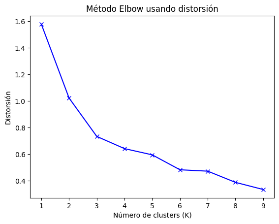

```
     Clusterización utilizando KMeans
```

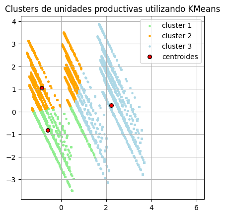

```
kmeans                                       1             2             3
index                      count  6.789300e+04  4.476500e+04  3.452800e+04
                           mean   7.029720e+04  7.945847e+04  1.497008e+05
                           std    4.647332e+04  4.976257e+04  1.853965e+04
NO_LLEVA_CONTABILIDAD      count  6.789300e+04  4.476500e+04  3.452800e+04
                           mean   1.428719e-02  5.300346e-01  2.109882e-01
                           std    1.186730e-01  4.991027e-01  4.080159e-01
ANTIGUEDAD_MAYOR_UN_AÑO    count  6.789300e+04  4.476500e+04  3.452800e+04
                           mean   9.827228e-01  5.266168e-01  8.037245e-01
                           std    1.303032e-01  4.992966e-01  3.971851e-01
INGRESOS                   count  6.789300e+04  4.476500e+04  3.452800e+04
                           mean   3.114116e+06  1.765297e+06  3.384760e+06
                           std    1.224259e+06  7.779443e+05  1.876390e+06
INTERES_CURSO              count  6.789300e+04  4.476500e+04  3.452800e+04
                           mean   2.798521e-02  5.269742e-02  9.249015e-01
                           std    1.649316e-01  2.234312e-01  2.635540e-01
INTERES_CREDITO            count  6.789300e+04  4.476500e+04  3.452800e+04
                           mean   2.761699e-02  6.473808e-02  9.155178e-01
                           std    1.638740e-01  2.460659e-01  2.781136e-01
PROPIETARIOS_MUJERES_dummy count  6.789300e+04  4.476500e+04  3.452800e+04
                           mean   3.994373e-01  5.482408e-01  5.558098e-01
                           std    4.897864e-01  4.976729e-01  4.968827e-01
x                          count  6.789300e+04  4.476500e+04  3.452800e+04
                           mean  -5.770084e-01 -8.498302e-01  2.236373e+00
                           std    4.326790e-01  5.156927e-01  6.268677e-01
y                          count  6.789300e+04  4.476500e+04  3.452800e+04
                           mean  -8.233922e-01  1.040646e+00  2.698693e-01
                           std    5.322080e-01  7.041289e-01  1.199102e+00
     d) Elección del perfil más adecuado entre los grupos
El cluster seleccionado es el  3
     e) Asignación de puntaje a cada potencial beneficiario
Cabeza
```

| index | NO_LLEVA_CONTABILIDAD | ANTIGUEDAD_MAYOR_UN_AÑO | INGRESOS | INTERES_CURSO | INTERES_CREDITO | PROPIETARIOS_MUJERES_dummy | kmeans | x | y | x_mean | y_mean | dist | NO_LLEVA_CONTABILIDAD_0 | NO_LLEVA_CONTABILIDAD_1 | ANTIGUEDAD_MAYOR_UN_AÑO_0 | ANTIGUEDAD_MAYOR_UN_AÑO_1 | INTERES_CURSO_0 | INTERES_CURSO_1 | INTERES_CREDITO_0 | INTERES_CREDITO_1 | PROPIETARIOS_MUJERES_dummy_0 | PROPIETARIOS_MUJERES_dummy_1 | x_mean_chosen | y_mean_chosen | dist_chosen | min_dist_order | Camino a la inclusión financiera |
| --- | --- | --- | --- | --- | --- | --- | --- | --- | --- | --- | --- | --- | --- | --- | --- | --- | --- | --- | --- | --- | --- | --- | --- | --- | --- | --- | --- |
| 150328 | 0 | 1 | 1650000.0 | 1 | 1 | 0 | 3 | 2.147935 | 0.238680 | 2.236373 | 0.269869 | 0.093777 | 1 | 0 | 0 | 1 | 0 | 1 | 0 | 1 | 1 | 0 | 2.236373 | 0.269869 | 0.093777 | 100.000000 | 100.000000 |
| 142548 | 0 | 1 | 1700000.0 | 1 | 1 | 0 | 3 | 2.157928 | 0.218146 | 2.236373 | 0.269869 | 0.093962 | 1 | 0 | 0 | 1 | 0 | 1 | 0 | 1 | 1 | 0 | 2.236373 | 0.269869 | 0.093962 | 99.995944 | 99.995944 |
| 135817 | 0 | 1 | 1700000.0 | 1 | 1 | 0 | 3 | 2.157928 | 0.218146 | 2.236373 | 0.269869 | 0.093962 | 1 | 0 | 0 | 1 | 0 | 1 | 0 | 1 | 1 | 0 | 2.236373 | 0.269869 | 0.093962 | 99.995944 | 99.995944 |
| 154717 | 0 | 1 | 1700000.0 | 1 | 1 | 0 | 3 | 2.157928 | 0.218146 | 2.236373 | 0.269869 | 0.093962 | 1 | 0 | 0 | 1 | 0 | 1 | 0 | 1 | 1 | 0 | 2.236373 | 0.269869 | 0.093962 | 99.995944 | 99.995944 |
| 135892 | 0 | 1 | 1700000.0 | 1 | 1 | 0 | 3 | 2.157928 | 0.218146 | 2.236373 | 0.269869 | 0.093962 | 1 | 0 | 0 | 1 | 0 | 1 | 0 | 1 | 1 | 0 | 2.236373 | 0.269869 | 0.093962 | 99.995944 | 99.995944 |
| 135059 | 0 | 1 | 1700000.0 | 1 | 1 | 0 | 3 | 2.157928 | 0.218146 | 2.236373 | 0.269869 | 0.093962 | 1 | 0 | 0 | 1 | 0 | 1 | 0 | 1 | 1 | 0 | 2.236373 | 0.269869 | 0.093962 | 99.995944 | 99.995944 |
| 165631 | 0 | 1 | 1700000.0 | 1 | 1 | 0 | 3 | 2.157928 | 0.218146 | 2.236373 | 0.269869 | 0.093962 | 1 | 0 | 0 | 1 | 0 | 1 | 0 | 1 | 1 | 0 | 2.236373 | 0.269869 | 0.093962 | 99.995944 | 99.995944 |
| 134376 | 0 | 1 | 1700000.0 | 1 | 1 | 0 | 3 | 2.157928 | 0.218146 | 2.236373 | 0.269869 | 0.093962 | 1 | 0 | 0 | 1 | 0 | 1 | 0 | 1 | 1 | 0 | 2.236373 | 0.269869 | 0.093962 | 99.995944 | 99.995944 |
| 136166 | 0 | 1 | 1700000.0 | 1 | 1 | 0 | 3 | 2.157928 | 0.218146 | 2.236373 | 0.269869 | 0.093962 | 1 | 0 | 0 | 1 | 0 | 1 | 0 | 1 | 1 | 0 | 2.236373 | 0.269869 | 0.093962 | 99.995944 | 99.995944 |
| 164400 | 0 | 1 | 1700000.0 | 1 | 1 | 0 | 3 | 2.157928 | 0.218146 | 2.236373 | 0.269869 | 0.093962 | 1 | 0 | 0 | 1 | 0 | 1 | 0 | 1 | 1 | 0 | 2.236373 | 0.269869 | 0.093962 | 99.995944 | 99.995944 |

```
Cola
```

| index | NO_LLEVA_CONTABILIDAD | ANTIGUEDAD_MAYOR_UN_AÑO | INGRESOS | INTERES_CURSO | INTERES_CREDITO | PROPIETARIOS_MUJERES_dummy | kmeans | x | y | x_mean | y_mean | dist | NO_LLEVA_CONTABILIDAD_0 | NO_LLEVA_CONTABILIDAD_1 | ANTIGUEDAD_MAYOR_UN_AÑO_0 | ANTIGUEDAD_MAYOR_UN_AÑO_1 | INTERES_CURSO_0 | INTERES_CURSO_1 | INTERES_CREDITO_0 | INTERES_CREDITO_1 | PROPIETARIOS_MUJERES_dummy_0 | PROPIETARIOS_MUJERES_dummy_1 | x_mean_chosen | y_mean_chosen | dist_chosen | min_dist_order | Camino a la inclusión financiera |
| --- | --- | --- | --- | --- | --- | --- | --- | --- | --- | --- | --- | --- | --- | --- | --- | --- | --- | --- | --- | --- | --- | --- | --- | --- | --- | --- | --- |
| 70224 | 1 | 0 | 100000.0 | 0 | 0 | 1 | 2 | -1.449557 | 3.139603 | -0.84983 | 1.040646 | 2.182955 | 0 | 1 | 1 | 0 | 1 | 0 | 1 | 0 | 0 | 1 | 2.236373 | 0.269869 | 4.671343 | 0.0 | 0.0 |
| 146620 | 1 | 0 | 100000.0 | 0 | 0 | 1 | 2 | -1.449557 | 3.139603 | -0.84983 | 1.040646 | 2.182955 | 0 | 1 | 1 | 0 | 1 | 0 | 1 | 0 | 0 | 1 | 2.236373 | 0.269869 | 4.671343 | 0.0 | 0.0 |
| 3890 | 1 | 0 | 100000.0 | 0 | 0 | 1 | 2 | -1.449557 | 3.139603 | -0.84983 | 1.040646 | 2.182955 | 0 | 1 | 1 | 0 | 1 | 0 | 1 | 0 | 0 | 1 | 2.236373 | 0.269869 | 4.671343 | 0.0 | 0.0 |
| 4823 | 1 | 0 | 100000.0 | 0 | 0 | 1 | 2 | -1.449557 | 3.139603 | -0.84983 | 1.040646 | 2.182955 | 0 | 1 | 1 | 0 | 1 | 0 | 1 | 0 | 0 | 1 | 2.236373 | 0.269869 | 4.671343 | 0.0 | 0.0 |
| 159249 | 1 | 0 | 100000.0 | 0 | 0 | 1 | 2 | -1.449557 | 3.139603 | -0.84983 | 1.040646 | 2.182955 | 0 | 1 | 1 | 0 | 1 | 0 | 1 | 0 | 0 | 1 | 2.236373 | 0.269869 | 4.671343 | 0.0 | 0.0 |
| 19804 | 1 | 0 | 100000.0 | 0 | 0 | 1 | 2 | -1.449557 | 3.139603 | -0.84983 | 1.040646 | 2.182955 | 0 | 1 | 1 | 0 | 1 | 0 | 1 | 0 | 0 | 1 | 2.236373 | 0.269869 | 4.671343 | 0.0 | 0.0 |
| 154000 | 1 | 0 | 100000.0 | 0 | 0 | 1 | 2 | -1.449557 | 3.139603 | -0.84983 | 1.040646 | 2.182955 | 0 | 1 | 1 | 0 | 1 | 0 | 1 | 0 | 0 | 1 | 2.236373 | 0.269869 | 4.671343 | 0.0 | 0.0 |
| 108024 | 1 | 0 | 100000.0 | 0 | 0 | 1 | 2 | -1.449557 | 3.139603 | -0.84983 | 1.040646 | 2.182955 | 0 | 1 | 1 | 0 | 1 | 0 | 1 | 0 | 0 | 1 | 2.236373 | 0.269869 | 4.671343 | 0.0 | 0.0 |
| 79843 | 1 | 0 | 100000.0 | 0 | 0 | 1 | 2 | -1.449557 | 3.139603 | -0.84983 | 1.040646 | 2.182955 | 0 | 1 | 1 | 0 | 1 | 0 | 1 | 0 | 0 | 1 | 2.236373 | 0.269869 | 4.671343 | 0.0 | 0.0 |
| 12132 | 1 | 0 | 100000.0 | 0 | 0 | 1 | 2 | -1.449557 | 3.139603 | -0.84983 | 1.040646 | 2.182955 | 0 | 1 | 1 | 0 | 1 | 0 | 1 | 0 | 0 | 1 | 2.236373 | 0.269869 | 4.671343 | 0.0 | 0.0 |

```python
np.random.seed(0) # Para asegurar que sea replicable

for nombre_programa in list_programas:
   x_res = mooi.mooi(nombre_programa, df_tropa, var_priorizacion, var_priorizacion_cont,
                 var_priorizacion_cat, mice_imputer, famd) # función con el proceso
   # Merge con los datos de contacto
   df_tropa_contacto = df_tropa_contacto.join(x_res[nombre_programa], lsuffix='_caller', rsuffix='_other')
```

### Guardar archivo de priorización

Este es el archivo que se le envía a la dirección que va a implementar el programa

```python
df_tropa_contacto.to_csv(output_path + 'Priorización Camino a la inclusión financiera.csv', index = False)
```

```python
# df_tropa_contacto.head(20)
```